# ECo 602 - Analysis of Environmental Data

Katrina Zarrella Smith

Fall 2020

# Introduction

Basic R components serve as foundational to advanced programming concepts. The following guide is a general overview of some of the components utilized in base R programming and frequentist statistics.

# RStudio Help

## Function Help

For any functions, put your cursor on the function in the console and press `F1` to get you to the help file of the function, or type `?` before the function argument in the console.

- If the complete function name is unknown, type `??` before the partial word in the console.

## The Global Environment

You can clear the workspace using `rm(list=ls())`.

```r
# clear R environment
rm(list=ls())
```

You can save the workspace when closing RStudio using `quit()` and selecting option `Y`. To save while working, use the `save.image()` function.

```r
#save the global environment
save.image()
```

## Citing

When citing RStudio, check the version year.

```r
# citation year
R.version$year
```

```
## [1] "2020"
```

Create a file named index.Rmd in your documents folder. Add text below the header. When you click the **Knit** button, a document will be generated that includes both content as well as the output of any embedded R code chunks within the document.

## Headers and Tabs

Header size is denoted by the number of `#` used before the text.

- `#` Large
- `##` Medium
- `###` Small

`{.tabset .tabset-pills}` creates tabbed content for all the following sections that are one-level below.

- If you include them on a primary header (one #), all of the subsequent secondary headers will in tabs.

## Code Chunks

You can embed an R code chunk using shortcuts:

- For Windows: ctrl + alt + i
- For Mac: command + option + i

Best practice is to give the chunk a name, it will appear in the navigation pane, using underscores for spaces. Be sure to always start the name with ‘r’.

```r
# This is my new code chunk

# Clear workspace
rm(list = ls())
```

You can comment large sections of text using shortcuts:

- Highlight all the chunk of code you want to comment: shift + ctrl + c
- To uncomment, highlight all the chunk of code you want to uncomment: shift + ctrl + c

Use `eval=FALSE` to keep the code chunk from being evaluated (only display the code chunk).

## Including Plots

To embed a plot, add it to your code chunk. Note that the `echo = FALSE` parameter was added to the code chunk to prevent printing of the R code that generated the plot.

You can adjust the size of the plots on your rendered document using the following code chunk arguments: `fig.height=`,`fig.width=`. You can adjust the aspect ratio using `fig.aspect=`.

Here’s an example with a penguins demo data set:

```r
# If not installed, install penguins data
install.packages('palmerpenguins')
```

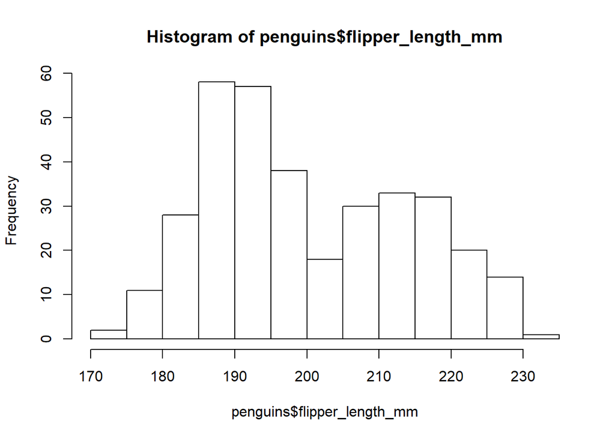

# Functions 1: Data Structure Functions

## `c()`

**Vectors with `c()`**

The `c()` function *combines* or *concatenates* elements into a vector (a 1-dimensional data structure consisting of 1 or more elements).

- All of the elements should be of the same type. Character and numeric types can be combined in the same call to `c()` but the elements will all be stored as characters.

Here’s some examples using numeric and character data types:

```r
# Create a vector of numbers
num_vec  = c(1, 4, 8, 9, 15)

# Create a vector of characters
char_vec = c('a', 'I love fish', 'data is cool')

# Create a vector of characters that includes numbers as characters
mixed_vec = c('Apple', 'Zebra', 1, 16)
```

View the contents of a vector by typing the name of the vector, or using the `print()` function.

Check the class of data using `class()`.

```r
# Type the name of the vector into the console to print the contents
num_vec
```

```
## [1]  1  4  8  9 15
```

```r
# The print() function accomplishes the same task
print(char_vec)
```

```
## [1] "a"            "I love fish"  "data is cool"
```

```r
# View the class of the data
class(mixed_vec)
```

```
## [1] "character"
```

## `seq()`

**Vectors with `seq()`**

Create a vector using sequential numbers with a minimum and maximum increased by 1 unit in between using `:`. The increment can also be customized by using `seq()`.

Here’s some examples:

```r
# Create a vector using 1 unit increments
my_vec1 = 1:10

# View
my_vec1
```

```
##  [1]  1  2  3  4  5  6  7  8  9 10
```

```r
# Create a vector using custom increments
my_vec2 = seq(0, 10, by = 2)

# View
my_vec2
```

```
## [1]  0  2  4  6  8 10
```

## `matrix()`

**Matrices**

A matrix is a two-dimensional data structure. Creating a matrix can be done with the function `matrix()` by specifying the elements to fill it with, the number of rows (`nrow`), and the number of columns (`ncol`).

- If either the number of rows *or* columns is specified, the other dimension argument is not needed.
- The matrix is populated by column as default. Use argument `byrow = TRUE` to populate elements by row.
- You can name the rows and/or columns with `dimnames`.
- You can repeat values in a matrix by supplying them in the first argument, then specifying the dimensions of the matrix.

Here’s some examples using numeric and character data types:

```r
# Create a 4x4 matrix populated by column
matrix(1:16, nrow = 4)
```

```
##      [,1] [,2] [,3] [,4]
## [1,]    1    5    9   13
## [2,]    2    6   10   14
## [3,]    3    7   11   15
## [4,]    4    8   12   16
```

```r
# Create a 4x4 matrix populated by row
my_matrix1 = matrix(1:16, nrow = 4, byrow = TRUE)

# View
my_matrix1
```

```
##      [,1] [,2] [,3] [,4]
## [1,]    1    2    3    4
## [2,]    5    6    7    8
## [3,]    9   10   11   12
## [4,]   13   14   15   16
```

```r
# Name the rows and columns
my_matrix2 = matrix(1:16, nrow = 4, dimnames = list(c('R1', 'R2', 'R3', 'R4'), c('C1', 'C2', 'C3', 'C4')))

# View
my_matrix2
```

```
##    C1 C2 C3 C4
## R1  1  5  9 13
## R2  2  6 10 14
## R3  3  7 11 15
## R4  4  8 12 16
```

```r
# Create a 4x5 matrix populated by row with recyled values
my_matrix3 = matrix(c(1, 16), nrow = 4, ncol = 5)

# View
my_matrix3
```

```
##      [,1] [,2] [,3] [,4] [,5]
## [1,]    1    1    1    1    1
## [2,]   16   16   16   16   16
## [3,]    1    1    1    1    1
## [4,]   16   16   16   16   16
```

```r
# Character and numeric variables can be mixed
my_matrix4 = matrix(c('A', 'Z', 1, 16), nrow = 4, ncol = 5)

# View
my_matrix4
```

```
##      [,1] [,2] [,3] [,4] [,5]
## [1,] "A"  "A"  "A"  "A"  "A"
## [2,] "Z"  "Z"  "Z"  "Z"  "Z"
## [3,] "1"  "1"  "1"  "1"  "1"
## [4,] "16" "16" "16" "16" "16"
```

```r
# The elements will all be converted to character data types
(my_matrix4)[3,1] # See subset() tab for subsetting detail
```

```
## [1] "1"
```

```r
class((my_matrix4)[3,1])
```

```
## [1] "character"
```

## `data.frame()`

**Data Frames**

A data frame is a two-dimensional data structure. Creating a data frame can be done with the function `data.frame()`. Assign each column a variable name by typing the name `=` and the elements.

- Variable names should not contain spaces and are case sensitive.
- Each column can contain a vector of any variable type.

Here’s some examples using numeric and character data types:

```r
# Build a data frame from scratch
dat_1 = data.frame(letters = c('b', 'w', 'B'),
                   numbers_1 = c(34, 6, 123454))

# View
dat_1
```

```
##   letters numbers_1
## 1       b        34
## 2       w         6
## 3       B    123454
```

## `subset()`

**Subsetting**

Subsets can be used to view, utilize, or discard specific segments of the data frame. Subset a data frame by using operators. You can combine a subset operator with a condition statement to select the specific segments of the data frame.

There are three main ways to do this:

- Use the `$` symbol. RStudio auto-populates the variable names which you can use as a drop-down menu to select the variable of interest. Alternately, if the name of a column is known, it can be typed after the `$`.

```r
# View
dat_1
```

```
##   letters numbers_1
## 1       b        34
## 2       w         6
## 3       B    123454
```

```r
# Subset a column by variable name
dat_1$letters
```

```
## [1] b w B
## Levels: b B w
```

- Use the `[]` indexing operator to select specific segments of the data. The first argument denotes the desired elements (leave blank to return all elements of the specified variable) and the second denotes the variable name of interest (leave blank to return all elements that meet the condition in the first argument).

```r
# Select the 'letters' column
dat_1[,'letters']
```

```
## [1] b w B
## Levels: b B w
```

```r
# Select the first two columns
dat_1[, c(1,2)]
```

```
##   letters numbers_1
## 1       b        34
## 2       w         6
## 3       B    123454
```

```r
# Select the first 2 elements from the 'letters' column
dat_1[1:2, 'letters']
```

```
## [1] b w
## Levels: b B w
```

```r
# Select elements greater than 6 from 'numbers_1' variable
dat_1[dat_1$numbers_1 > 6, 'numbers_1']
```

```
## [1]     34 123454
```

```r
# Select elements greater than 6 from 'numbers_1' variable and return 'letters' elements
dat_1[dat_1$numbers_1 > 6, 'letters']
```

```
## [1] b B
## Levels: b B w
```

```r
# Select rows that include elements greater than 6 from 'numbers_1' variable
dat_1[dat_1$numbers_1 > 6,]
```

```
##   letters numbers_1
## 1       b        34
## 3       B    123454
```

```r
# Select rows that include elements equal to 6 from 'numbers_1' variable
dat_1[dat_1$numbers_1==6,]
```

```
##   letters numbers_1
## 2       w         6
```

- Use the `subset()` function to select specific segments of the data.

```r
# Select rows that include elements greater than 6 from 'numbers_1' variable
subset(dat_1, subset = numbers_1 > 6)
```

```
##   letters numbers_1
## 1       b        34
## 3       B    123454
```

```r
# Name the subset to store it as a data frame
my_subset = subset(dat_1, subset = numbers_1 > 6)

print(my_subset)
```

```
##   letters numbers_1
## 1       b        34
## 3       B    123454
```

- Use `dplyr` functions to select segments of the data frame:
  - `select()`
  - `filter()`

```r
require(dplyr)

# Select the variables from the data frame
select(dat_1, letters, numbers_1)
```

```
##   letters numbers_1
## 1       b        34
## 2       w         6
## 3       B    123454
```

```r
# Select all the variables from the data frame
select(dat_1, letters:numbers_1)
```

```
##   letters numbers_1
## 1       b        34
## 2       w         6
## 3       B    123454
```

```r
# Exclude from the data frame
select(dat_1, -letters)
```

```
##   numbers_1
## 1        34
## 2         6
## 3    123454
```

```r
# Select data that meets a condition
filter(dat_1, letters == "b") # , for 'or' and & for 'and' to add multiple conditions
```

```
##   letters numbers_1
## 1       b        34
```

## `length()`

**Counting with `length()`**

The `length()` function can be used with vectors to count the number of elements. When combined with subsetting a data frame, it can count the total observations that meet the subset conditions.

- `length()` can be used on either numeric and character data types.

Here’s some examples using vector and data frame types:

```r
# View
num_vec
```

```
## [1]  1  4  8  9 15
```

```r
# Count the number of elements in the vector 'num_vec'
length(num_vec)
```

```
## [1] 5
```

```r
# View
char_vec
```

```
## [1] "a"            "I love fish"  "data is cool"
```

```r
# Count the number of elements in the vector 'char_vec'
length(char_vec)
```

```
## [1] 3
```

```r
# View
dat_1$letters
```

```
## [1] b w B
## Levels: b B w
```

```r
# Count the number of elements in the subsetted vector
length(dat_1$letters)
```

```
## [1] 3
```

## `nrow()`

**Counting with `nrow()`**

The `nrow()` function can be used with matrices or data frames to count the number of rows.

- The `nrow()` argument does not count the row with column headers.

Here’s some examples using data frame and matrix types:

```r
# View
dat_1
```

```
##   letters numbers_1
## 1       b        34
## 2       w         6
## 3       B    123454
```

```r
# Count the number of rows
nrow(dat_1)
```

```
## [1] 3
```

```r
# View
my_matrix4
```

```
##      [,1] [,2] [,3] [,4] [,5]
## [1,] "A"  "A"  "A"  "A"  "A"
## [2,] "Z"  "Z"  "Z"  "Z"  "Z"
## [3,] "1"  "1"  "1"  "1"  "1"
## [4,] "16" "16" "16" "16" "16"
```

```r
# Count the number of rows in a matrix with headers
nrow(my_matrix4)
```

```
## [1] 4
```

## `ncol()`

**Counting with `ncol()`**

The `ncol()` function can be used with matrices or data frames to count the number of columns.

- The `ncol()` argument does not count the column with row headers.

Here’s some examples using data frame and matrix types:

```r
# View
dat_1
```

```
##   letters numbers_1
## 1       b        34
## 2       w         6
## 3       B    123454
```

```r
# Count the number of columns
ncol(dat_1)
```

```
## [1] 2
```

```r
# View
my_matrix4
```

```
##      [,1] [,2] [,3] [,4] [,5]
## [1,] "A"  "A"  "A"  "A"  "A"
## [2,] "Z"  "Z"  "Z"  "Z"  "Z"
## [3,] "1"  "1"  "1"  "1"  "1"
## [4,] "16" "16" "16" "16" "16"
```

```r
# Count the number of columns in a matrix with headers
ncol(my_matrix4)
```

```
## [1] 5
```

## `dim()`

**Counting with `dim()`**

The `dim()` function can be used with matrices or data frames to count the number of columns and rows or *dimensions*.

- The `dim()` argument does not count the row or column headers.

Here’s some examples using data frame and matrix types:

```r
# View
my_matrix1
```

```
##      [,1] [,2] [,3] [,4]
## [1,]    1    2    3    4
## [2,]    5    6    7    8
## [3,]    9   10   11   12
## [4,]   13   14   15   16
```

```r
# Dimensions of a matrix
dim(my_matrix1)
```

```
## [1] 4 4
```

```r
# View
my_matrix2
```

```
##    C1 C2 C3 C4
## R1  1  5  9 13
## R2  2  6 10 14
## R3  3  7 11 15
## R4  4  8 12 16
```

```r
# Dimensions of a matrix that has row and column headers
dim(my_matrix2)
```

```
## [1] 4 4
```

```r
# View
dat_1
```

```
##   letters numbers_1
## 1       b        34
## 2       w         6
## 3       B    123454
```

```r
# Dimensions of a data frame that has column headers
dim(dat_1)
```

```
## [1] 3 2
```

# Functions 2: Numerical Data Exploration

## `head()`

**Previewing a data frame with `head()`**

Use the head() function to print the first few lines of a data frame.

Here’s an example with a penguins demo data set:

```r
# If not installed, install penguins data set
install.packages('palmerpenguins')
```

```r
# Load the penguins package
require(palmerpenguins)

head(penguins)
```

```
## # A tibble: 6 x 8
##   species island bill_length_mm bill_depth_mm flipper_length_~ body_mass_g sex
##   <fct>   <fct>           <dbl>         <dbl>            <int>       <int> <fct>
## 1 Adelie  Torge~           39.1          18.7              181        3750 male
## 2 Adelie  Torge~           39.5          17.4              186        3800 fema~
## 3 Adelie  Torge~           40.3          18                195        3250 fema~
## 4 Adelie  Torge~           NA            NA                 NA          NA <NA>
## 5 Adelie  Torge~           36.7          19.3              193        3450 fema~
## 6 Adelie  Torge~           39.3          20.6              190        3650 male
## # ... with 1 more variable: year <int>
```

## `summary()`

**Previewing a data frame with `summary()`**

The `summary()` function is useful in checking data that you have read into RStudio as well as getting a general overview of the data. It will list all variables and give summary statistics for numeric variables.

- If the variable type is numeric, it will return the minimum, 1st quartile, median, mean, 3rd quartile, and maximum.
- If the variable type is character, it will return counts for the number of times each element appears in the variable.

```r
# View the summary for a data frame
summary(dat_1)
```

```
##  letters   numbers_1
##  b:1     Min.   :     6
##  B:1     1st Qu.:    20
##  w:1     Median :    34
##          Mean   : 41165
##          3rd Qu.: 61744
##          Max.   :123454
```

## `mean()`

**Summary statistics**

The mean is calculated by adding up all the numbers and dividing that by the total number of values. Calculating the mean can be done with `mean()` for numeric vectors.

```r
# Calculate the mean
mean(c(2,4,6))
```

```
## [1] 4
```

```r
# View
dat_1$numbers_1
```

```
## [1]     34      6 123454
```

```r
# Calculate the mean of a subsetted vector from a data frame
mean(dat_1$numbers_1)
```

```
## [1] 41164.67
```

## `sd()`

**Summary statistics**

The standard deviation is calculated by the square root of a variable’s variance. Calculating the standard deviation can be done with `sd()` for numeric vectors.

```r
# Calculate the standard deviation
sd(c(2,4,6))
```

```
## [1] 2
```

```r
# View
dat_1$numbers_1
```

```
## [1]     34      6 123454
```

```r
# Calculate the mean of a subsetted vector from a data frame
sd(dat_1$numbers_1)
```

```
## [1] 71264.65
```

# Functions 3: Graphical Data Exploration

## `plot()`

**Scatterplots**

Scatterplots can be created using `plot()` for continuous data.

Here’s an example with a penguins demo data set:

```r
# If not installed, install penguins data set
install.packages('palmerpenguins')
```

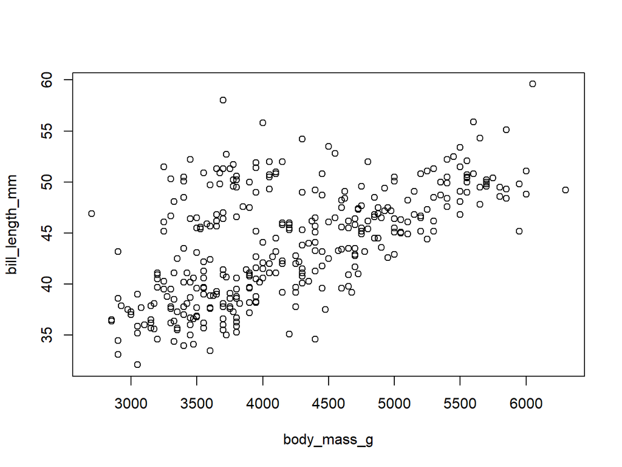

```r
# Load the penguins package
require(palmerpenguins)

# Using formula notation, the response variable is on the left side, followed by the tilde expression '~', and then all the explanatory variables are on the right side. The name of the data frame follows.
plot(bill_length_mm ~ body_mass_g, data = penguins)
```

- There are many arguments which can be used to customize the aesthetics of the plot.

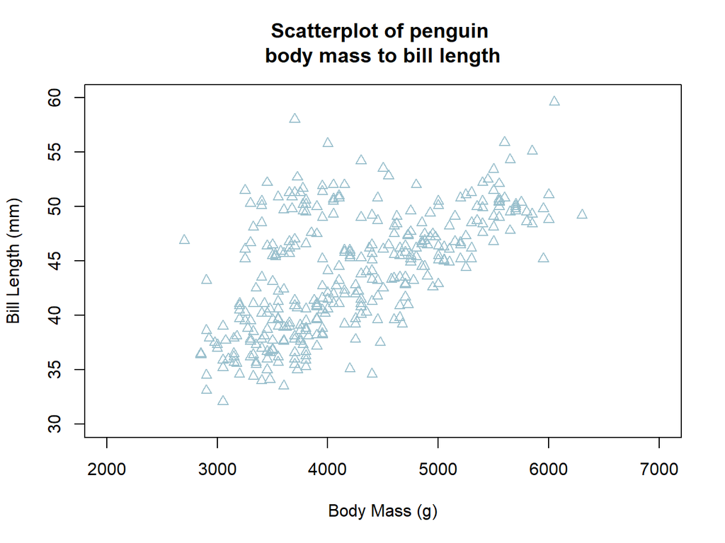

```r
plot(bill_length_mm ~ body_mass_g, data = penguins,
     col = 'lightblue3', # Change the color of the symbol
     pch = 2, # Change the shape of the symbol
     cex = 1, # Change the size of the symbol
     main = 'Scatterplot of penguin \nbody mass to bill length', # Add a plot title; split the title into two lines with the '\n' argument
     xlab = 'Body Mass (g)', # Customize the x-axis label
     ylab = 'Bill Length (mm)', # Customize the y-axis label
     xlim = c(2000, 7000), # Customize the x-axis with lower and upper limits
     ylim = c(30, 60)) # Customize the y-axis with lower and upper limits
```

Colors can be called by name or hexadecimal code.

- Named colors can be found using `colors()` or online images: http://www.stat.columbia.edu/~tzheng/files/Rcolor.pdf

The most common `pch` arguments are:

pch = 0, square

pch = 1, circle

pch = 2, triangle point up

pch = 3, plus

pch = 4, cross

pch = 5, diamond

pch = 6, triangle point down

pch = 7, square cross

pch = 8, star

pch = 9, diamond plus

pch = 10, circle plus

pch = 11, triangles up and down

pch = 12, square plus

pch = 13, circle cross

pch = 14, square and triangle down

pch = 15, filled square

pch = 16, filled circle

pch = 17, filled triangle point-up

pch = 18, filled diamond

pch = 19, solid circle

pch = 20, bullet (smaller circle)

pch = 21, filled circle blue

pch = 22, filled square blue

pch = 23, filled diamond blue

pch = 24, filled triangle point-up blue

pch = 25, filled triangle point down blue

## `hist()`

**Histograms**

Histograms show the frequency of binned vector data. Histograms can be created using `hist()`.

Here’s an example with a penguins demo data set:

```r
# If not installed, install penguins data set
install.packages('palmerpenguins')
```

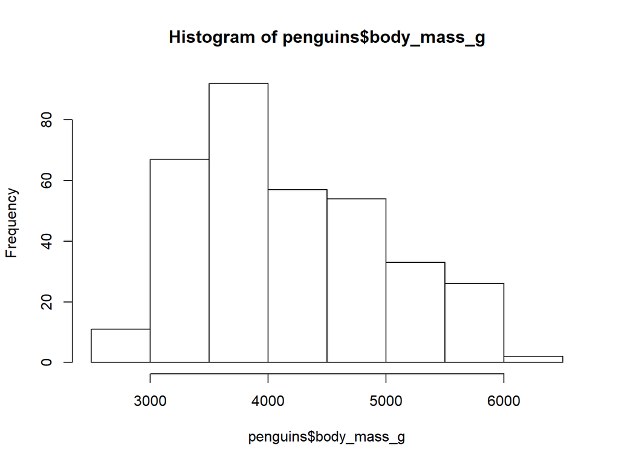

```r
# Load the penguins package
require(palmerpenguins)

# Using subsetting notation, a vector from the data frame is called.
hist(penguins$body_mass_g)
```

- There are many arguments which can be used to customize the aesthetics of the histogram.

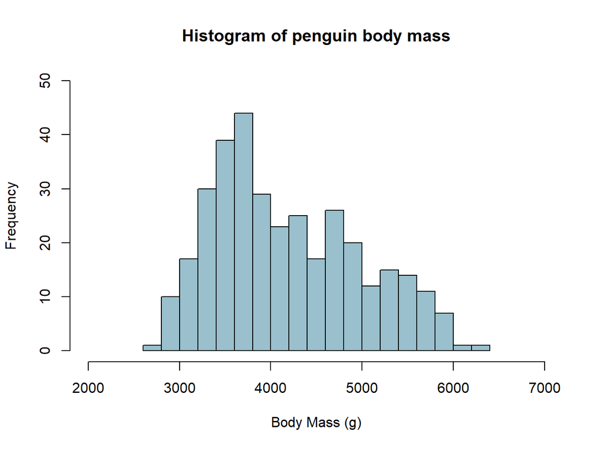

```r
hist(penguins$body_mass_g,
     col = 'lightblue3', # Change the color of the bars
     main = 'Histogram of penguin body mass', # Customize the plot title
     xlab = 'Body Mass (g)', # Customize the x-axis label
     ylab = 'Frequency', # Customize the y-axis label
     xlim = c(2000, 7000), # Customize the x-axis with lower and upper limits
     ylim = c(0, 50), # Customize the y-axis with lower and upper limits
     breaks = 20) # Change the size of the bins to match your data
```

## `boxplot()`

**Boxplots**

Boxplots can be created using `boxplot()` for continuous combined with categorical data.

- Conditional boxplots can be made using 1 continuous and 1 or more categorical variables.

Here’s an example with a penguins demo data set:

```r
# If not installed, install penguins data set
install.packages('palmerpenguins')
```

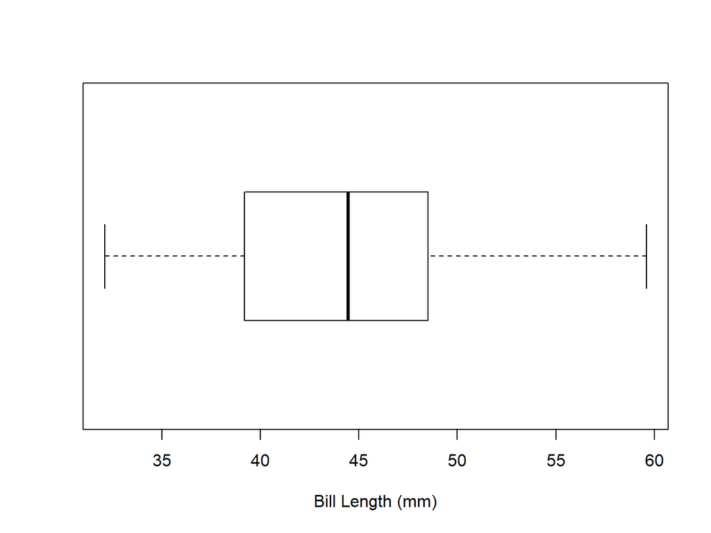

```r
# Load the penguins package
require(palmerpenguins)

# Create a simple boxplot
boxplot(penguins$bill_length_mm,
        xlab = 'Bill Length (mm)', # Add an x-axis label
        horizontal = TRUE) # Rotate the boxplot
```

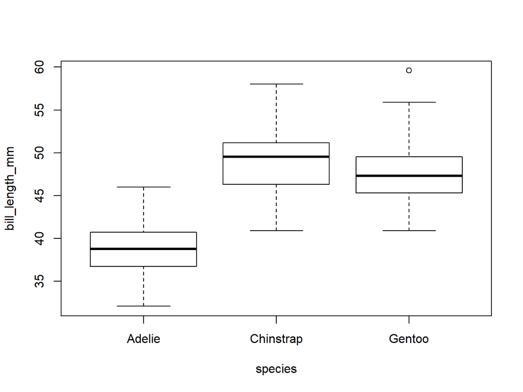

```r
# Using formula notation, the response variable is on the left side, followed by the tilde expression '~', and then the categorical explanatory variable is on the right side. The name of the data frame follows.
boxplot(bill_length_mm ~ species, data = penguins)
```

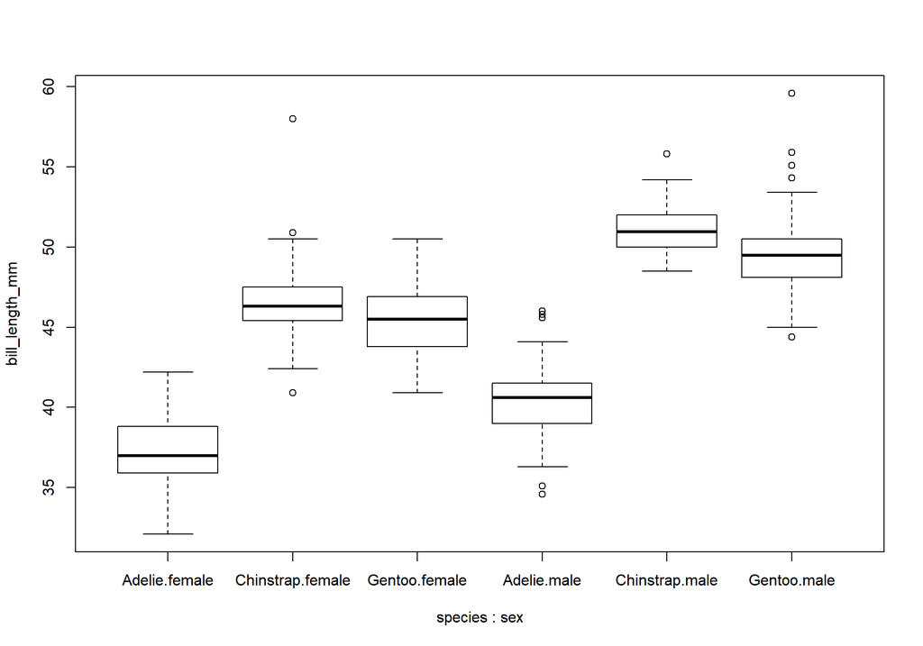

```r
# Multiple explanatory variables can be used by adding '*' between variable names
boxplot(bill_length_mm ~ species*sex, data = penguins)
```

- There are many arguments which can be used to customize the aesthetics of the plot.

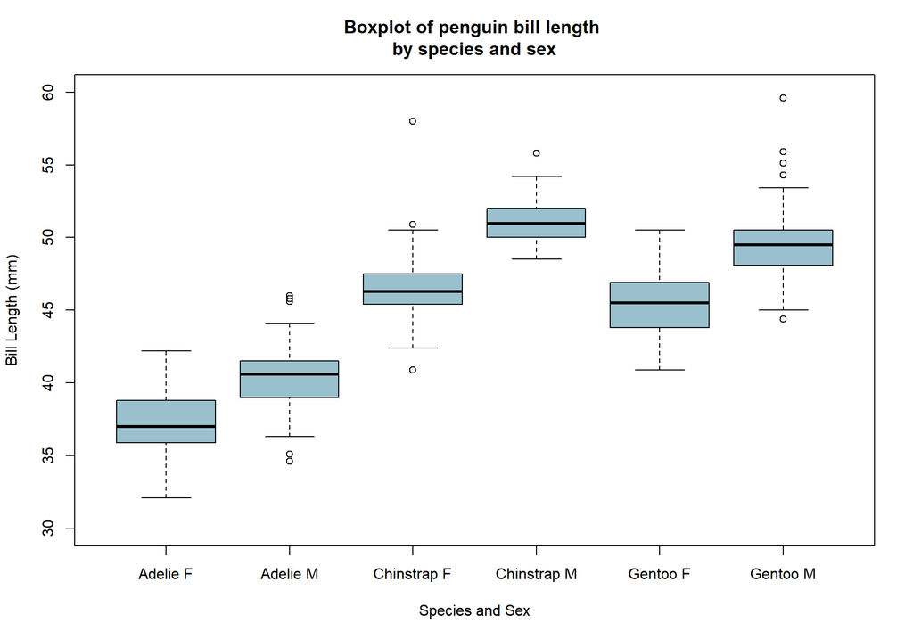

```r
boxplot(bill_length_mm ~ sex*species, data = penguins,
        col = 'lightblue3', # Change the color of the symbol
        main = 'Boxplot of penguin bill length \nby species and sex', # Add a plot title; split the title into two lines with the '\n' argument
        names = c('Adelie F', 'Adelie M',
                  'Chinstrap F', 'Chinstrap M',
                  'Gentoo F', 'Gentoo M'), #Customize the x-axis tick mark labels
        xlab = 'Species and Sex', # Customize the x-axis label
        ylab = 'Bill Length (mm)', # Customize the y-axis label
        ylim = c(30, 60)) # Customize the y-axis with lower and upper limits
```

## `par()` and `mfrow =`

**Multiple plots**

Parameters for plots can be customized using the `par()` function. When combined with `mfrow =`, multiple plots can be printed in the plot window.

- The number of rows and columns can be specified. The first number is for number of rows, and the second is for columns.

```r
# If not installed, install penguins data set
install.packages('palmerpenguins')
```

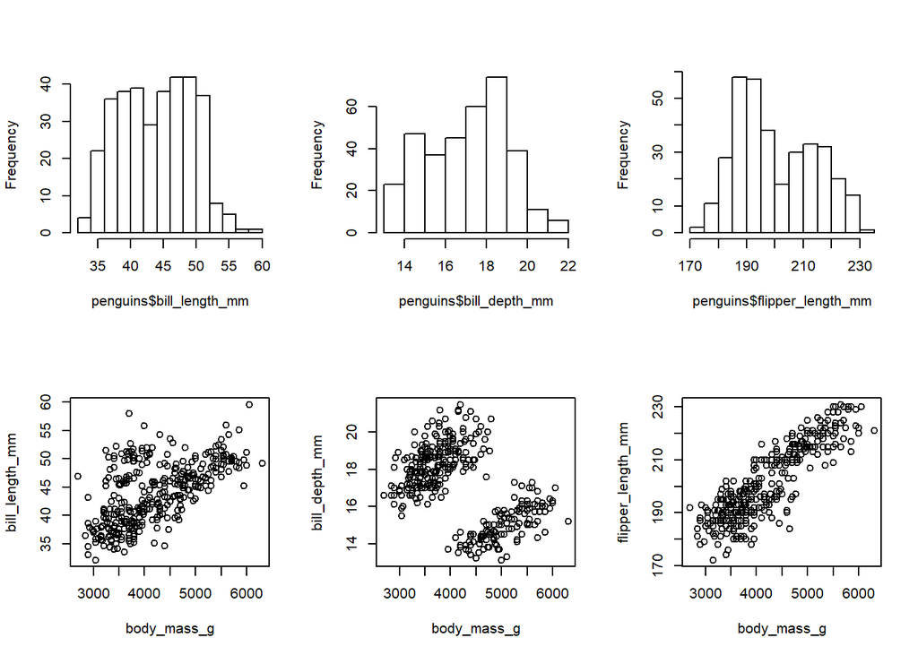

```r
# Load the penguins package
require(palmerpenguins)

# Create a plot window with 6 plots
par(mfrow = c(2,3))

# Plot 1, top row
hist(penguins$bill_length_mm,
     main = NULL) # Remove the plot title

# Plot 2, top row
hist(penguins$bill_depth_mm,
     main = NULL) # Remove the plot title

# Plot 3, top row
hist(penguins$flipper_length_mm,
     main = NULL) # Remove the plot title

# Plot 4, bottom row
plot(bill_length_mm ~ body_mass_g, data = penguins)

# Plot 5, bottom row
plot(bill_depth_mm ~ body_mass_g, data = penguins)

# Plot 6, bottom row
plot(flipper_length_mm ~ body_mass_g, data = penguins)
```

(!) Reset the plot window after plotting:

```r
dev.off()
```

# Functions 4: Distribution Functions

## Functions for normal distributions

## `dnorm()`

The Probability Density Function, i.e. the height of the curve at `x`, can be calculated by `dnorm()` for normal distributions. It is the probability of the random variable `x` falling within a particular range of values, as opposed to taking on any one value.

- The default settings are `mean = 0` and `sd = 1`.

```r
# The Probability Density Function for a normal distribution
x = 5 # Set the value for x or call in the dnorm()
dnorm(x, mean = 2, sd = 3)
```

```
## [1] 0.08065691
```

```r
dnorm(5, 2, 3)
```

```
## [1] 0.08065691
```

## `pnorm()`

The Cumulative Density Function, i.e. the area under the curve left of `q`, can be calculated by `pnorm()` for normal distributions. It is the probability that a value of `q` or less is observed. Alternatively, it can be the area under the curve right of `q`, or the probability that a value of `q` or more is observed.

- The default settings are `mean = 0`, `sd = 1`, and `lower.tail = TRUE` for a value of `q` or less.
- Set `lower.tail = FALSE` for a value of `q` or more.

```r
#The Cumulative Density Function for a normal distribution
q = 5 # Set the value for q or call in the pnorm()
pnorm(q, mean = 2, sd = 3, lower.tail = FALSE)
```

```
## [1] 0.1586553
```

```r
pnorm(5, 2, 3, lower.tail = FALSE)
```

```
## [1] 0.1586553
```

## `qnorm()`

The quantile function, i.e. the `p` percentile, can be calculated by `qnorm` for normal distributions (`p` is the decimal version of the percentage). It is the inverse function of the Cumulative Density Function.

- The default settings are `mean = 0`, `sd = 1`, and `lower.tail = TRUE` for a value of `p` or less.
- Set `lower.tail = FALSE` for a value of `p` or more.

```r
#The quantile function for a normal distribution
p = 0.6 # Set the value for p or call in the qnorm()
qnorm(p, mean = 2, sd = 3, lower.tail = FALSE)
```

```
## [1] 1.239959
```

```r
qnorm(0.6, 2, 3, lower.tail = FALSE)
```

```
## [1] 1.239959
```

## Functions for binomial distributions

## `dbinom()`

The Probability Density Function can be calculated by `dbinom()` for binomial distributions. The number of successes `x` in a sample with a fixed number of trials (`size`) and an equal probability of success (`prob`) in every trial can be specified in `dbinom()`. `dbinom()` calculates the probability of having exactly `x` successes.

- The `size` argument is the number of trials, which can be 0 or more.
- The `prob` argument is the probability of success on each trial in decimal form.

```r
# The Probability Density Function for a binomial distribution
x = 5 # Set the value for x or call in the dbinom()
dbinom(x, size = 20, prob = 0.3)
```

```
## [1] 0.1788631
```

```r
dbinom(5, 20, 0.3)
```

```
## [1] 0.1788631
```

## `pbinom()`

The Cumulative Density Function, i.e. the area to the left of `q`, can be calculated by `pbinom()` for binomial distributions. The number of successes `q` in a sample with a fixed number of trials (`size`) and an equal probability of success (`prob`) in every trial can be specified in `pbinom()`. `pbinom()` calculates the probability of having `q` or less successes. Alternatively, it can be the the probability of having `q` or more successes, or the area to the right of `q`.

- The `size` argument is the number of trials, which can be 0 or more.
- The `prob` argument is the probability of success on each trial in decimal form.
- A default setting is `lower.tail = TRUE` for a value of `q` or less. Set `lower.tail = FALSE` for a value of `q` or more.

```r
#The Cumulative Density Function for a binomial distribution
q = 5 # Set the value for q or call in the pbinom()
pbinom(q, size = 20, prob = 0.3, lower.tail = FALSE)
```

```
## [1] 0.5836292
```

```r
pbinom(5, 20, 0.3, lower.tail = FALSE)
```

```
## [1] 0.5836292
```

## `qbinom()`

The quantile function, i.e. the `p` percentile, can be calculated by `qbinom` for binomial distributions (`p` is the decimal version of the percentage). It is the inverse function of the Cumulative Density Function.

- The `size` argument is the number of trials, which can be 0 or more.
- The `prob` argument is the probability of success on each trial in decimal form.
- A default setting is `lower.tail = TRUE` for a value of `q` or less. Set `lower.tail = FALSE` for a value of `q` or more.

```r
#The quantile function for a binomial distribution
p = 0.6 # Set the value for p or call in the qbinom()
qbinom(p, size = 20, prob = 0.3, lower.tail = FALSE)
```

```
## [1] 5
```

```r
qbinom(0.6, 20, 0.3, lower.tail = FALSE)
```

```
## [1] 5
```

# Functions 5: Other Functions

## Loading packages

Packages must be installed using `install.packages()`.

To load the package after installing, you can use either `libary()` or `require()`. The benefits of each are as follows:

- `libary()` generates an error if the package is not installed whereas `require()` generates a warning. This means that if the package is loaded with `require()` without being installed, the error will occur when trying to use that package whereas `library()` will let you know immediately if there is an error.
- `require()` is good for code that will be shared because you can check if the package is installed, and either load it if installed already, or install and load it if not.

Here’s an example with the package ‘here’:

```r
if (!require(here)) install.packages('here')
library(here)
```

## Reading a csv file

Import data from a csv (comma-separated value) file into RStudio using `read.csv()`.

- The working directory must be set to the location of the csv file on your computer using `setwd()`.

```r
dat_birds = read.csv('hab.sta.csv')
```

- Alternatively, use the package ‘here’ to skip setting a working directory.

```r
# If not installed, install 'here'
install.packages('here')
```

```r
# Load the 'here' package
require(here)

# Load a csv file with the first argument as the name of the folder where the csv file is stored and the second argument as the name of the file.
dat_birds = read.csv(here('data', 'hab.sta.csv'))

# Troubleshooting here(), use the double colon to access the specific package then the specific function.
dat_birds = read.csv(here::here('data', 'hab.sta.csv'))
```

# Part 2: Data Analysis

The following is analysis on data collected on two species of small mammals in the Atlantic forests of Brazil.

First, let’s load the data:

```r
# If not installed, install 'here'
install.packages('here')
```

```r
# Load the 'here' package
require(here)

# Upload the data
dat_delomys = read.csv(here("data", "delomys.csv"))
```

# Numerical Exploration

Now I will explore basic statistics for the data:

```r
# Display summary statistics for body mass
summary(dat_delomys$body_mass)
```

```
##    Min. 1st Qu.  Median    Mean 3rd Qu.    Max.
##    5.00   35.00   43.00   44.06   54.00  105.00
```

```r
# Display summary statistics for body length
summary(dat_delomys$body_length)
```

```
##    Min. 1st Qu.  Median    Mean 3rd Qu.    Max.
##    49.0   106.0   116.0   114.7   124.0   265.0
```

```r
# Test body mass and body length for normality.
shapiro.test(dat_delomys$body_mass)
```

```
##
##  Shapiro-Wilk normality test
##
## data:  dat_delomys$body_mass
## W = 0.99506, p-value = 4.33e-05
```

```r
shapiro.test(dat_delomys$body_mass)
```

```
##
##  Shapiro-Wilk normality test
##
## data:  dat_delomys$body_mass
## W = 0.99506, p-value = 4.33e-05
```

The null hypothesis for the Shapiro-Wilk test is: “The data were sampled from a normally distributed population.” This means a p < 0.05 = not normally distributed.

# Graphical Exploration

Next I will explore the data visually. Since the points will overlap, I will choose a color with transparency to display the data more clearly:

```r
# Set a color to be transparent, on a scale from 0 to 1
my_colors <- rgb(red=0.2, green=0.4, blue=0.7, alpha=0.4)
```

## Scatterplot

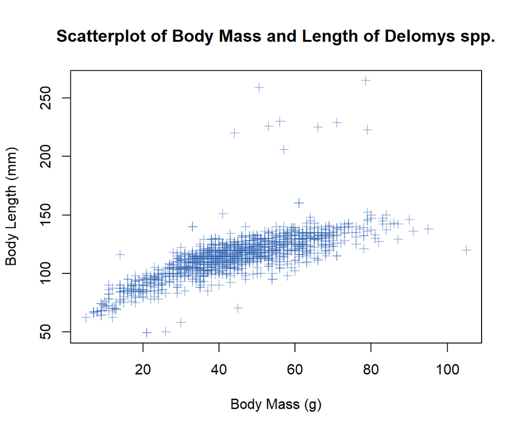

```r
# Create a scatterplot
plot(dat_delomys$body_mass, dat_delomys$body_length,
     main = 'Scatterplot of Body Mass and Length of Delomys spp.',
     xlab = 'Body Mass (g)',
     ylab = 'Body Length (mm)',
     col = my_colors, # Custom color
     pch = 3) # Change the data point symbol
```

## Body Mass

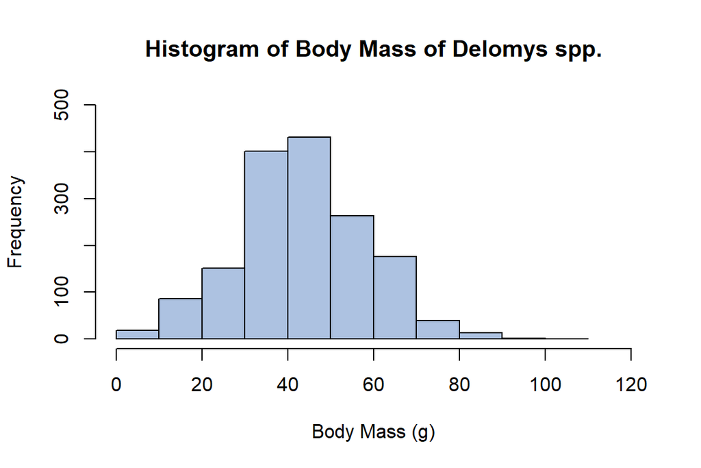

```r
# Plot a histogram of body mass
hist(dat_delomys$body_mass,
     xlab = 'Body Mass (g)',
     main = 'Histogram of Body Mass of Delomys spp.',
     xlim = c(0,120), # Expand x-axis limit
     ylim = c(0,500), # Expand y-axis limit
     col = my_colors)
```

Note that the shape of the distribution does not appear normal as it shows a small right-skew / tail in the data. This matches with the results of the Shapiro-Wilk normality test providing evidence that body mass was not sampled from a normally distributed population.

## Body Length

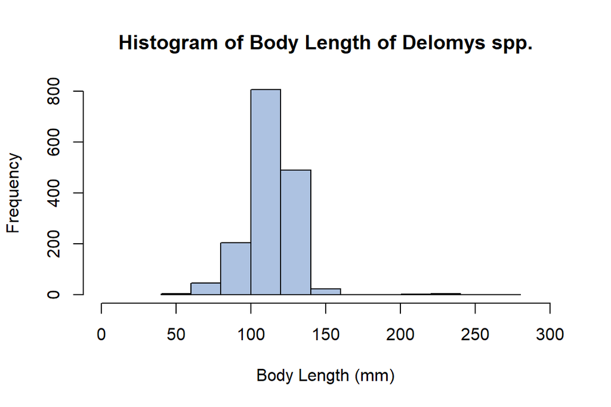

```r
#Plot a histogram of body length
hist(dat_delomys$body_length,
     xlab = 'Body Length (mm)',
     main = 'Histogram of Body Length of Delomys spp.',
     xlim = c(0,300), # Expand x-axis limit
     ylim = c(0,800), # Expand y-axis limit
     col = my_colors)
```

## Species

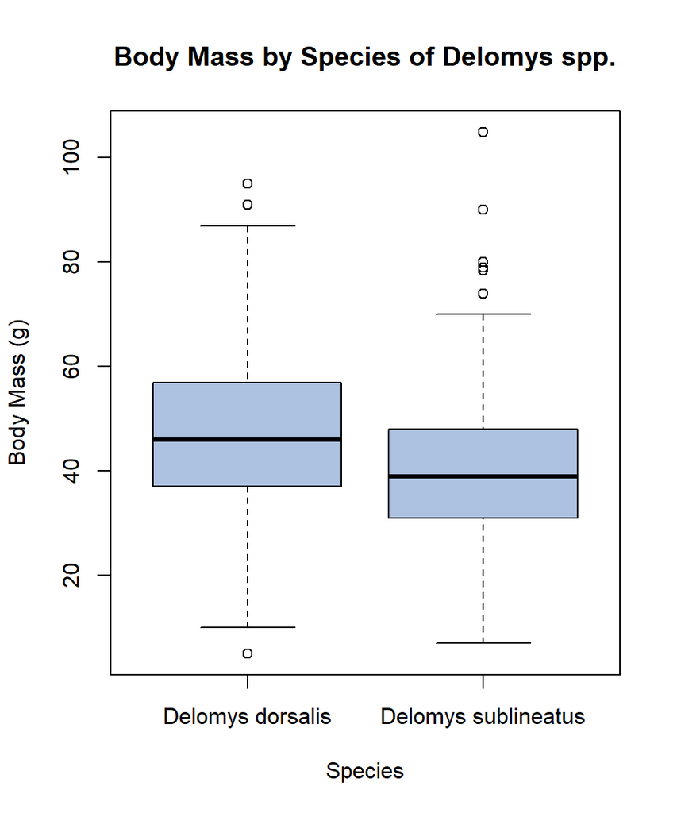

```r
# Conditional boxplot of body mass grouped by species
plot(dat_delomys$binomial,
     dat_delomys$body_mass,
     xlab = 'Species',
     ylab = 'Body Mass (g)',
     main = 'Body Mass by Species of Delomys spp.',
     col = my_colors)
```

Note that D. sublineatus appear to be slightly lighter than D. dorsalis.

## Sex

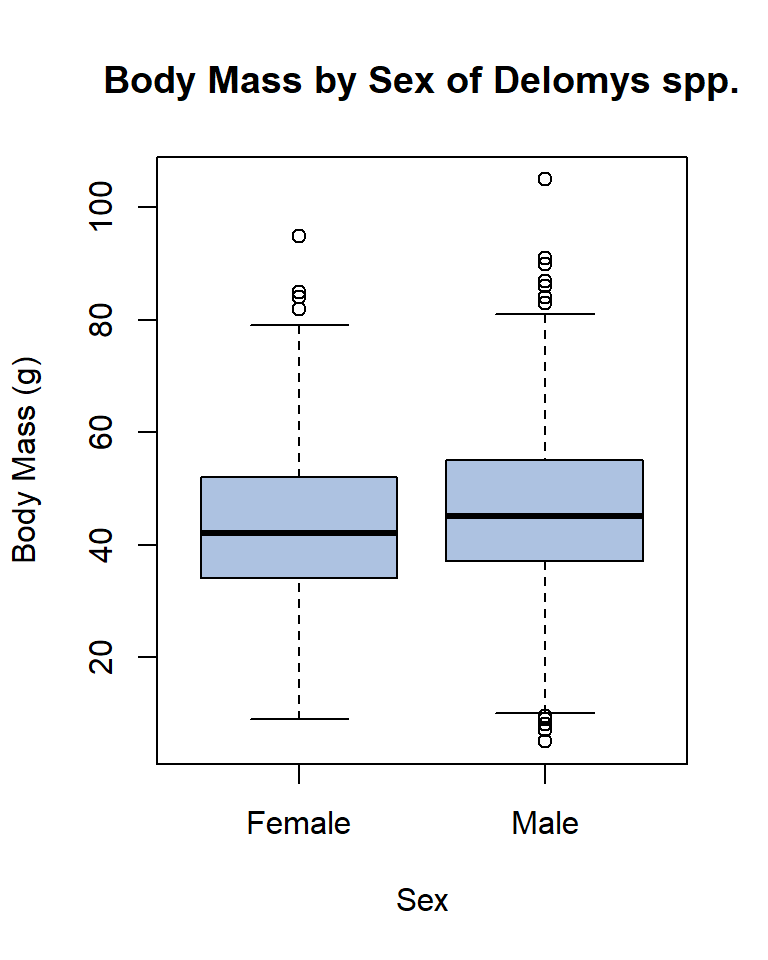

```r
# Conditional boxplot of body mass grouped by sex
plot(dat_delomys$sex,
     dat_delomys$body_mass,
     names = c('Female', 'Male'), #Customize the x-axis tick mark labels
     xlab = 'Sex',
     ylab = 'Body Mass (g)',
     main = 'Body Mass by Sex of Delomys spp.',
     col = my_colors)
```

Note that the body mass between females and males of Delomys spp. does not appear to be dramatically different.

## Species and Sex

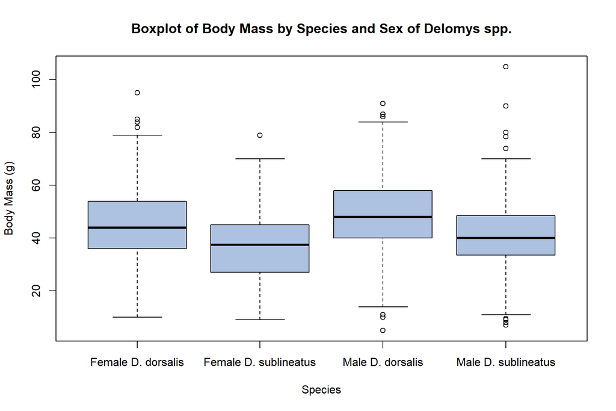

```r
# Conditional boxplot of body mass grouped by species and sex
boxplot(body_mass ~ binomial * sex,
     data = dat_delomys,
     names = c('Female D. dorsalis', 'Female D. sublineatus',
                    'Male D. dorsalis', 'Male D. sublineatus'),
     xlab = 'Species',
     ylab = 'Body Mass (g)',
     main = 'Boxplot of Body Mass by Species and Sex of Delomys spp.',
     col = my_colors)
```

Note, the body mass between D. dorsalis and D. sublineatus split by sex appear to show differences between some of the groups. The greatest differences are:

- D. sublineatus appear slightly lighter than D. dorsalis.
- Females appear slightly lighter when compared to males of the same species.

# Model Building

Next I will build linear models:

```r
# Model 1: simple linear regression body_length ~ body_mass
fit1 = lm(body_length ~ body_mass, data = dat_delomys)

# Model 2: 1-way ANOVA body_mass ~ sex
fit2 = lm(body_mass ~ sex, data = dat_delomys)

# Model 3: 1-way ANOVA body_mass ~ binomial
fit3 = lm(body_mass ~ binomial, data = dat_delomys)

# Model 4: 2-way additive ANOVA body_mass ~ sex + binomial
fit4 = lm(body_mass ~ sex + binomial, data = dat_delomys)

# Model 5: 2-way factorial ANOVA body_mass ~ sex * binomial
fit5 = lm(body_mass ~ sex * binomial, data = dat_delomys)
```

# Model Diagnostics

Let’s check whether the models fulfill the assumption of normality of the residuals using a graphical and numerical approach.

## `fit1`

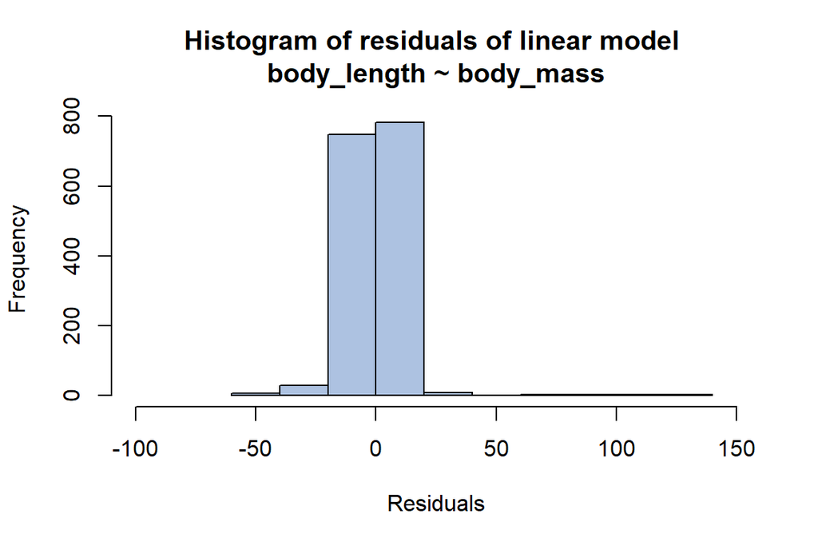

```r
# Graphical
hist(residuals(fit1),
     main = 'Histogram of residuals of linear model \nbody_length ~ body_mass',
     xlab = 'Residuals',
     xlim = c(-100,150),
     col = my_colors)
```

```r
# Numerical
shapiro.test(fit1$residuals)
```

```
##
##  Shapiro-Wilk normality test
##
## data:  fit1$residuals
## W = 0.73462, p-value < 2.2e-16
```

Both the histogram, with a very high peak and right-skew, and the Shapiro-Wilk test provide evidence that the residuals for this model are not normally distributed.

## `fit2`

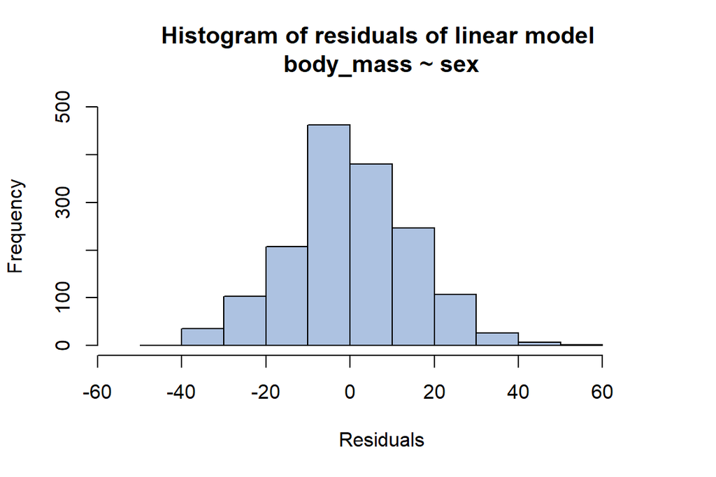

```r
# Graphical
hist(residuals(fit2),
     main = 'Histogram of residuals of linear model \nbody_mass ~ sex',
     xlab = 'Residuals',
     xlim = c(-55,70),
     ylim = c(0,500),
     col = my_colors)
```

```r
# Numerical
shapiro.test(fit2$residuals)
```

```
##
##  Shapiro-Wilk normality test
##
## data:  fit2$residuals
## W = 0.99563, p-value = 0.0001541
```

The histogram appears to be somewhat normally distributed. However, the Shapiro-Wilk test provides evidence that the residuals for this model are not normally distributed.

## `fit3`

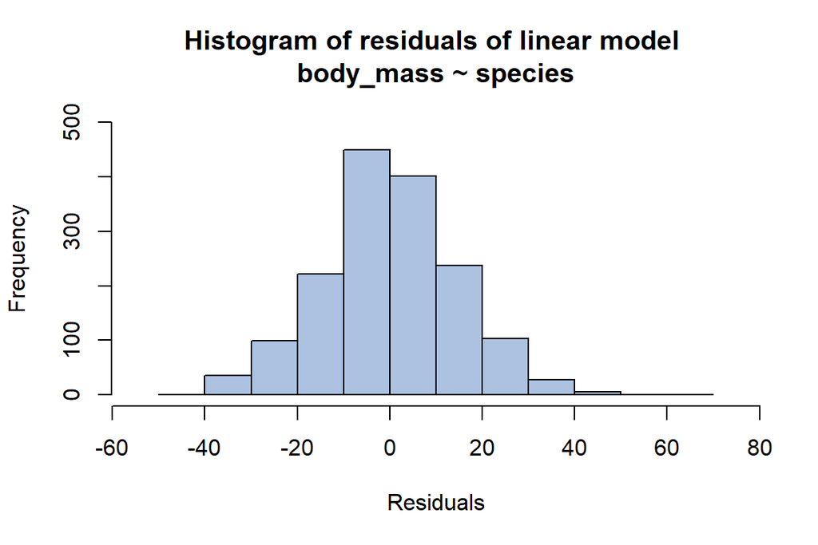

```r
# Graphical
hist(residuals(fit3),
     main = 'Histogram of residuals of linear model \nbody_mass ~ species',
     xlab = 'Residuals',
     xlim = c(-55,75),
     ylim = c(0,500),
     col = my_colors)
```

```r
# Numerical
shapiro.test(fit3$residuals)
```

```
##
##  Shapiro-Wilk normality test
##
## data:  fit3$residuals
## W = 0.99535, p-value = 8.103e-05
```

The histogram appears to be somewhat normally distributed with a very small right-skew. However, the Shapiro-Wilk test provides evidence that the residuals for this model are not normally distributed.

## `fit4`

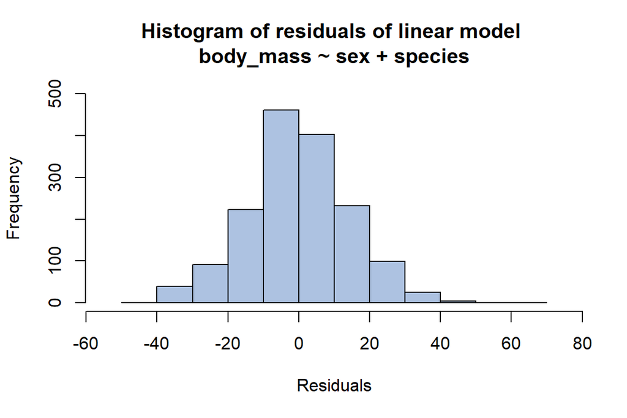

```r
# Graphical
hist(residuals(fit4),
     main = 'Histogram of residuals of linear model \nbody_mass ~ sex + species',
     xlab = 'Residuals',
     xlim = c(-55,75),
     ylim = c(0,500),
     col = my_colors)
```

```r
# Numerical
shapiro.test(fit4$residuals)
```

```
##
##  Shapiro-Wilk normality test
##
## data:  fit4$residuals
## W = 0.99525, p-value = 6.805e-05
```

The histogram appears to be somewhat normally distributed but with a very small right-skew. However, the Shapiro-Wilk test provides evidence that the residuals for this model are not normally distributed.

## `fit5`

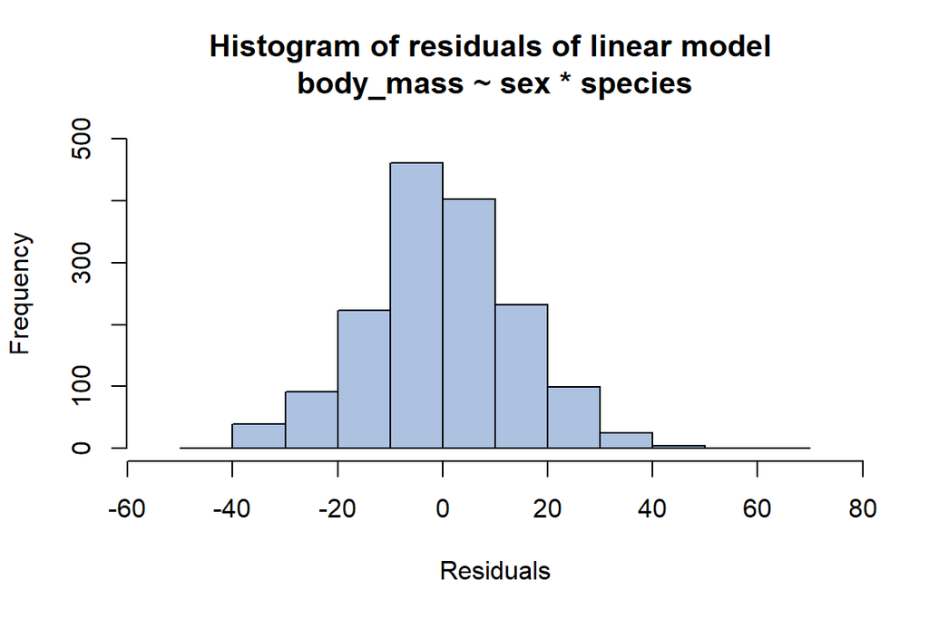

```r
# Graphical
hist(residuals(fit5),
     main = 'Histogram of residuals of linear model \nbody_mass ~ sex * species',
     xlab = 'Residuals',
     xlim = c(-55,75),
     ylim = c(0,500),
     col = my_colors)
```

```r
# Numerical
shapiro.test(fit5$residuals)
```

```
##
##  Shapiro-Wilk normality test
##
## data:  fit5$residuals
## W = 0.99526, p-value = 6.816e-05
```

The histogram appears to be somewhat normally distributed but with a very small right-skew. However, the Shapiro-Wilk test provides evidence that the residuals for this model are not normally distributed.

## Summary

Note that although none of the fitted models passed normality assumption tests, the largest violation was `fit1`. The other four models’ histograms showed somewhat normally distributed values.

# Coefficient tables

Let’s look at the coefficient tables:

## `fit1`

```r
knitr::kable(coef(summary(fit1)), digits=4)
```

|  | Estimate | Std. Error | t value | Pr(>\|t\|) |
| --- | --- | --- | --- | --- |
| (Intercept) | 76.1247 | 0.9158 | 83.1226 | 0 |
| body_mass | 0.8755 | 0.0197 | 44.4630 | 0 |

Note:

- The mass/length relationship is two orders of magnitude different.
- The expected body length of an an animal that weighs 100g is

= Intercept + Estimate * X

= 76.1247 + 0.8755 * 100

= 163.6747 mm

- The expected body length of an animal that weighs 0g is

= Intercept + Estimate * X

= 76.1247 + 0.8755 * 0

= Intercept + Estimate * X

= 76.1247 mm

## `fit2`

```r
knitr::kable(coef(summary(fit2)), digits=4)
```

|  | Estimate | Std. Error | t value | Pr(>\|t\|) |
| --- | --- | --- | --- | --- |
| (Intercept) | 42.7115 | 0.5289 | 80.7564 | 0e+00 |
| sexmale | 2.7841 | 0.7456 | 3.7340 | 2e-04 |

## `fit3`

```r
knitr::kable(coef(summary(fit3)), digits=4)
```

|  | Estimate | Std. Error | t value | Pr(>\|t\|) |
| --- | --- | --- | --- | --- |
| (Intercept) | 46.7524 | 0.4500 | 103.8958 | 0 |
| binomialDelomys sublineatus | -7.6831 | 0.7605 | -10.1032 | 0 |

## `fit4`

```r
knitr::kable(coef(summary(fit4)), digits=4)
```

|  | Estimate | Std. Error | t value | Pr(>\|t\|) |
| --- | --- | --- | --- | --- |
| (Intercept) | 45.0704 | 0.5556 | 81.1139 | 0 |
| sexmale | 3.7954 | 0.7260 | 5.2281 | 0 |
| binomialDelomys sublineatus | -8.1935 | 0.7610 | -10.7668 | 0 |

## `fit5`

```r
knitr::kable(coef(summary(fit5)), digits=4)
```

|  | Estimate | Std. Error | t value | Pr(>\|t\|) |
| --- | --- | --- | --- | --- |
| (Intercept) | 45.0555 | 0.6053 | 74.4352 | 0.0000 |
| sexmale | 3.8281 | 0.8967 | 4.2692 | 0.0000 |
| binomialDelomys sublineatus | -8.1417 | 1.1281 | -7.2172 | 0.0000 |
| sexmale:binomialDelomys sublineatus | -0.0950 | 1.5286 | -0.0622 | 0.9504 |

## Summary

- The base level for sex is female.
- The base level for binomial/species is Delomys dorsalis.
- Males are heavier.
- Delomys dorsalis are heavier.

# ANOVA tables

Let’s look at the ANOVA tables:

## `fit2`

```r
knitr::kable(anova(fit2), digits=4)
```

|  | Df | Sum Sq | Mean Sq | F value | Pr(>F) |
| --- | --- | --- | --- | --- | --- |
| sex | 1 | 3061.678 | 3061.6779 | 13.9429 | 2e-04 |
| Residuals | 1578 | 346507.131 | 219.5863 | NA | NA |

## `fit3`

```r
knitr::kable(anova(fit3), digits=4)
```

|  | Df | Sum Sq | Mean Sq | F value | Pr(>F) |
| --- | --- | --- | --- | --- | --- |
| binomial | 1 | 21289.68 | 21289.6805 | 102.0751 | 0 |
| Residuals | 1583 | 330164.45 | 208.5688 | NA | NA |

## `fit4`

```r
knitr::kable(anova(fit4), digits=4)
```

|  | Df | Sum Sq | Mean Sq | F value | Pr(>F) |
| --- | --- | --- | --- | --- | --- |
| sex | 1 | 3061.678 | 3061.6779 | 14.9584 | 1e-04 |
| binomial | 1 | 23727.134 | 23727.1342 | 115.9232 | 0e+00 |
| Residuals | 1577 | 322779.997 | 204.6798 | NA | NA |

## `fit5`

```r
knitr::kable(anova(fit5), digits=4)
```

|  | Df | Sum Sq | Mean Sq | F value | Pr(>F) |
| --- | --- | --- | --- | --- | --- |
| sex | 1 | 3061.6779 | 3061.6779 | 14.9489 | 0.0001 |
| binomial | 1 | 23727.1342 | 23727.1342 | 115.8500 | 0.0000 |
| sex:binomial | 1 | 0.7914 | 0.7914 | 0.0039 | 0.9504 |
| Residuals | 1576 | 322779.2058 | 204.8091 | NA | NA |

## Summary

- Sex and species are significant predictors for body mass.
- The interaction between sex and species was not significant (p = 0.9504).
- The significance (as measured by p-value) for either of the main effects (sex and species) did not differ much between the single-predictor models, the additive model, and the interactive model.

For sex, fit2: p = 0.000195, fit4: p = 0.000114, fit5: 0.000115

For species, fit3: p = 0.0000, fit4: p = 0.0000, fit5: p=0.0000

# Model Comparison

Let’s compare the model AICs:

```r
AIC(fit2)
```

```
## [1] 13006.8
```

```r
AIC(fit3)
```

```
## [1] 12966.36
```

```r
AIC(fit4)
```

```
## [1] 12896.73
```

```r
AIC(fit5)
```

```
## [1] 12898.72
```

- Models 4 and 5 have the lowest AIC.

I would select models 4 and 5. There is not much of a difference in AIC between model 4 and model 5 and the next lowest AIC is more than 5 units away from the second lowest AIC. Because the joint effect of sex and species was not statistically significant in model 5, these models have somewhat similar results. They are a reasonable fit and lead to coefficients that are reasonably close in values. Ecological explanations for the main effects by themselves can be done with model 4: females and males are associated with different body masses and D. dorsalis and D. sublineatus are associated with different body masses. Additionally, by disregarding the interaction factor, the model is simpler. Discussing model 5 with an interaction term would only be necessary if the interaction between sex and species was ecologically significant.